# Msl3 patients - HDACi treatment - ChIPseq correlation

Giuseppe Semplicio

2/16/2018

# Part 3

How do the genes that are bound by MSL or NSL behave in our RNAseq of patients?

##### MSL/NSL bound genes at TSS - expression levels

##### Which mouse genes have a ChIP peak at TSS, at gene body or distal?

update 20180301:  
we will focus on protein_coding genes only (see 02-get_coding_genes_only.txt for how to get the protein coding genes) for the identification of the distal peaks’ closest gene - because we want to assign the peak to a gene and avoid it being assigned to a snRNA or pseudogene etc

looking at the TSS and genebody peaks for MSL2, the genes found are almost exclusively protein_coding so the initial analysis is fine and the results won’t change much  
However, to be correct I will run the intersectBed again a TSS and gene bed file that contain only the protein coding genes (based on protein_coding_ENSMUSG.txt). To get this bed files I used the R commands describe in 02-get_coding_genes_only.txt.

Procedure to prepare the bed files and perform the overlap with TSS and genes is found in:  
01-prepare_bed_files_readme.txt  
02-get_coding_genes_only.txt  
03-overlap_chip_peaks_with_genes_TSS_readme.txt

Now, let’s get the genes that have a peak at TSS, genebody or distal

```
## Number of genes with TSS, genebody or distal peak in mouse
```

```
##      mcrs1_mlES_TSS mcrs1_mlES_genebody        mof_mlES_TSS
##                8795                2480                2380
##   mof_mlES_genebody       mof_mlNPC_TSS  mof_mlNPC_genebody
##                 190                1148                  14
##       msl1_mlES_TSS  msl1_mlES_genebody       msl2_mlES_TSS
##                 629                 350                1002
##  msl2_mlES_genebody      msl2_mlNPC_TSS msl2_mlNPC_genebody
##                1214                2065                1807
##       nsl3_mlES_TSS  nsl3_mlES_genebody      nsl3_mlNPC_TSS
##                4115                 475                6666
## nsl3_mlNPC_genebody  MCRS1_mlES_closest    MOF_mlES_closest
##                 384                4446                 313
##   MOF_mlNPC_closest   MSL1_mlES_closest   MSL2_mlES_closest
##                  32                 457                1503
##  MSL2_mlNPC_closest   NSL3_mlES_closest  NSL3_mlNPC_closest
##                2323                 916                 749
```

[output not shown]

```
##      mcrs1_mlES_TSS mcrs1_mlES_genebody        mof_mlES_TSS
##                8213                1773                2347
##   mof_mlES_genebody       mof_mlNPC_TSS  mof_mlNPC_genebody
##                 177                1160                  14
##       msl1_mlES_TSS  msl1_mlES_genebody       msl2_mlES_TSS
##                 603                 322                 935
##  msl2_mlES_genebody      msl2_mlNPC_TSS msl2_mlNPC_genebody
##                1004                1987                1413
##       nsl3_mlES_TSS  nsl3_mlES_genebody      nsl3_mlNPC_TSS
##                4007                 418                6434
## nsl3_mlNPC_genebody  MCRS1_mlES_closest    MOF_mlES_closest
##                 341                2702                 272
##   MOF_mlNPC_closest   MSL1_mlES_closest   MSL2_mlES_closest
##                  27                 398                1162
##  MSL2_mlNPC_closest   NSL3_mlES_closest  NSL3_mlNPC_closest
##                1499                 748                 596
```

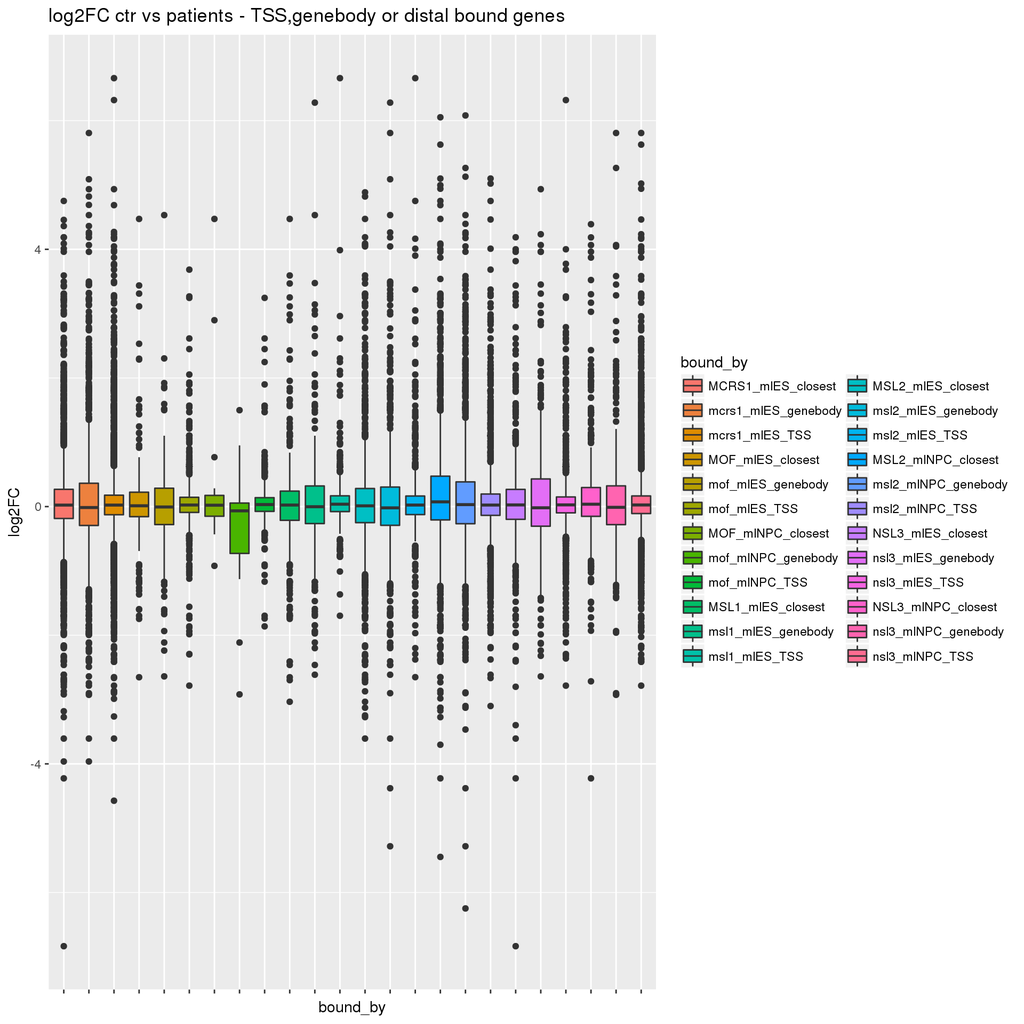

```
## The mean, median and sd of log2FC of the individual ChIP categories
```

```
## # A tibble: 24 x 4
##    bound_by               mean   median    sd
##    <chr>                 <dbl>    <dbl> <dbl>
##  1 MCRS1_mlES_closest   0.0757  0.0235  0.776
##  2 mcrs1_mlES_genebody  0.0794 -0.0146  0.917
##  3 mcrs1_mlES_TSS       0.0514  0.0235  0.509
##  4 MOF_mlES_closest     0.0642  0.0127  0.745
##  5 mof_mlES_genebody    0.0176 -0.00620 0.831
##  6 mof_mlES_TSS         0.0362  0.0247  0.329
##  7 MOF_mlNPC_closest    0.258   0.0215  1.07
##  8 mof_mlNPC_genebody  -0.348  -0.0662  1.14
##  9 mof_mlNPC_TSS        0.0441  0.0315  0.295
## 10 MSL1_mlES_closest    0.0421  0.0242  0.841
## # ... with 14 more rows
```

##### How many DEgenes are bound by MSL/NSL members?

Back to Bash.  
The whole procedure on getting the closest up- and downstream protein coding gene is described in 04-get_closest_distal_peak.txt. update 2018-03-07:  
I will use the closest gene, regardless whether up- or downstream

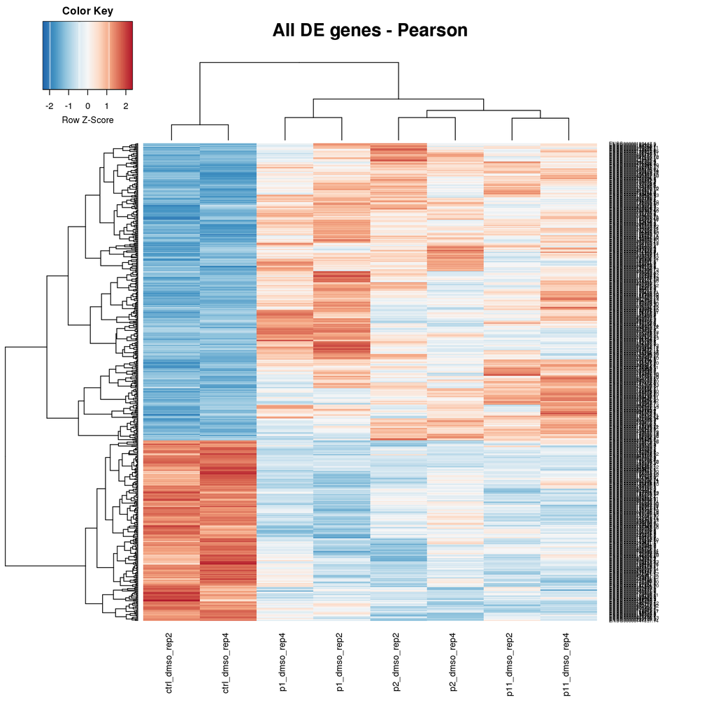

```
## -1 = not bound, 0 = no orthologue, 1 = bound
```

###### Upstream regulator

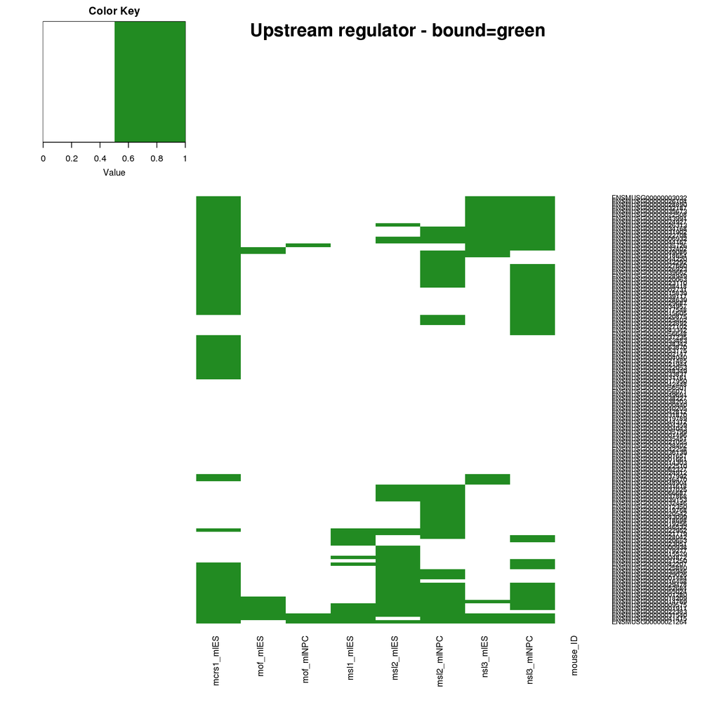

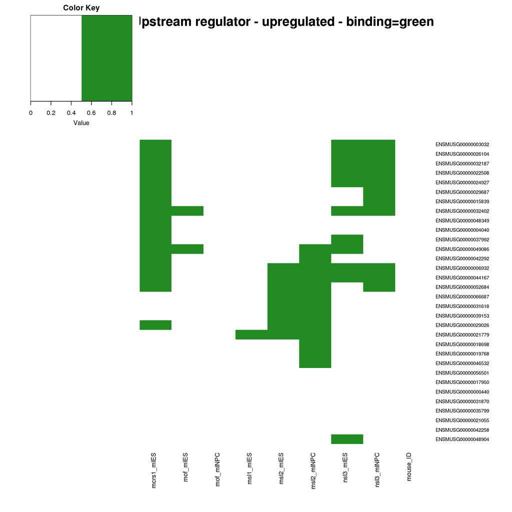

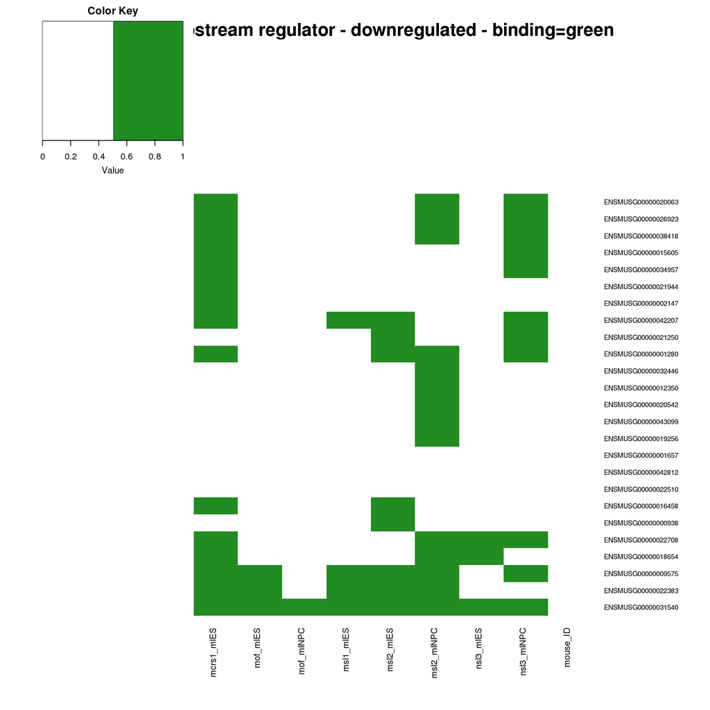

###### A “fancy” pahtways figure

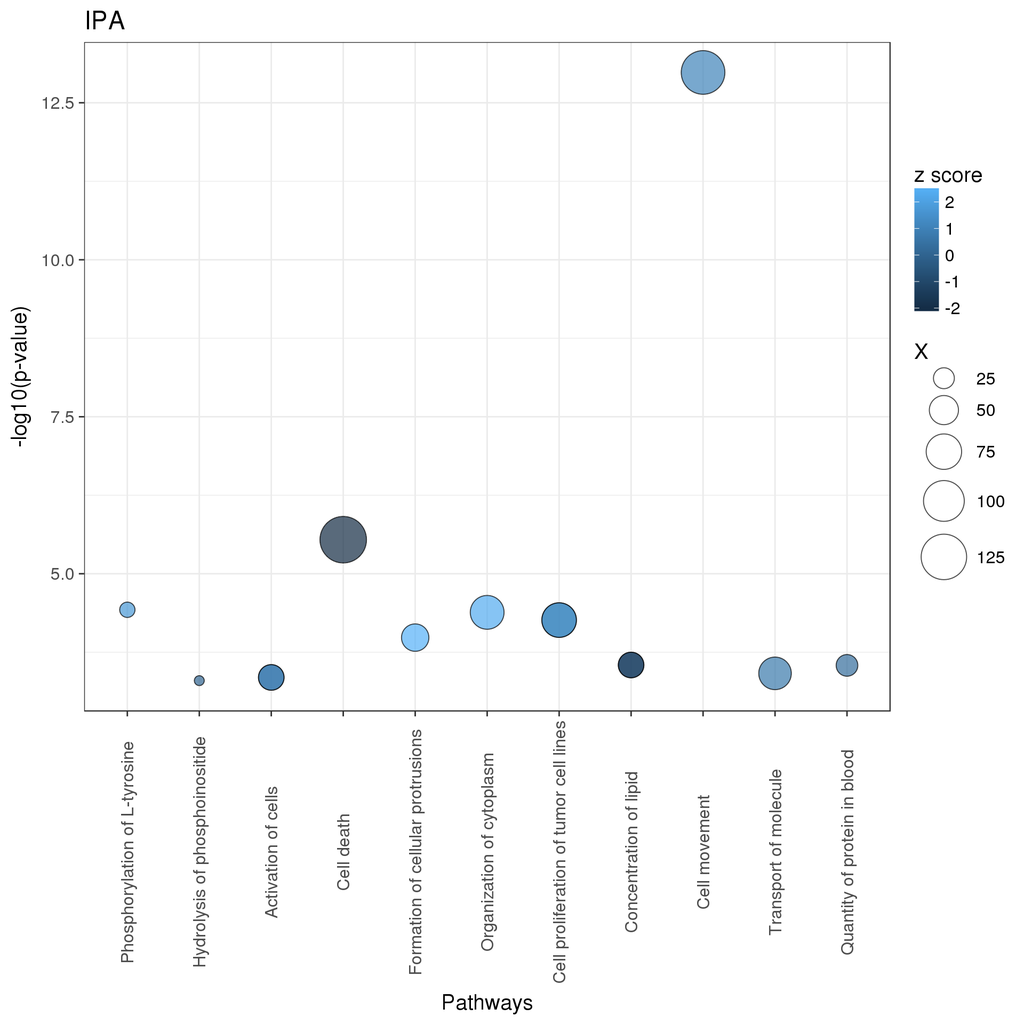

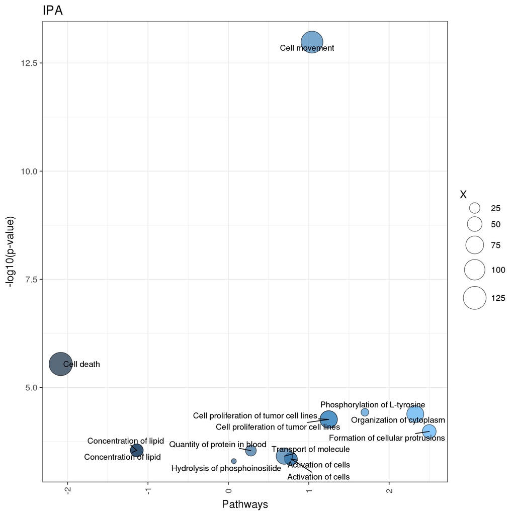

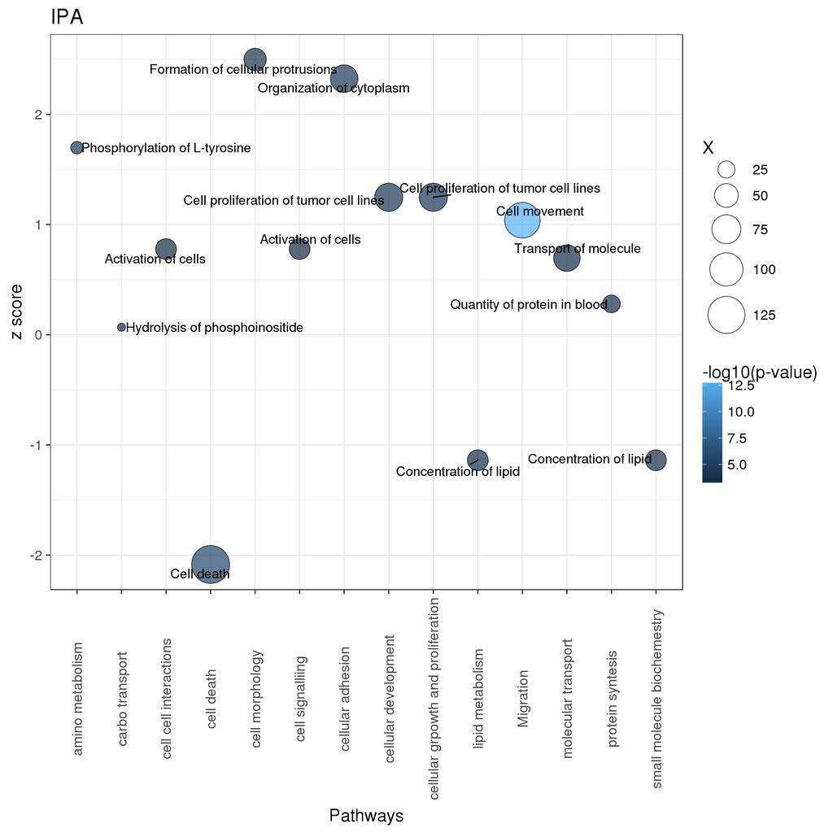